# Autocorrelação espacial

### transformando os pontos em raster

Nosso arquivo de bias é será um raster, logo precisamos transformar nossos pontos em raster para ter um ponto de saída.  
Nas próximas linhas vamos então:  
1. criar um objeto apenas com lat e long 2. criar um raster com a função `rasterize` 3. plotar para checar se está tudo Ok.

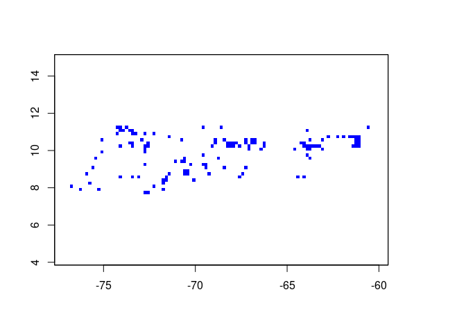

```r
#1. criando o objeto occ
occ<- df[,c("LONG", "LAT")]
#2. usando a funçõa rasterize. Note que a função pede:
#a) os pontos; b) um objeto de referência; c) um valor para dar ao pontos
occur.ras <- rasterize(occ, env, 1)
#3 plotando
plot(occur.ras, col="blue", legend=F)
```

Agora vamos extrair alguns dados dessa camada que acabamos de criar:

```r
#nessa primeira linha, pegamos as células que tem
#valor = 1, ou seja as células que correspondem aos
#pontos de amostragem
presences <- which(values(occur.ras)==1)
#Aqui pegamos as coordenadas x e y de cada célula
pres.locs <- coordinates(occur.ras)[presences,]

#veja como eles se parecem
head(presences)
```

```
## [1] 675 676 678 703 709 757
```

```r
head(pres.locs)
```

```
##              x     y
## [1,] -74.25000 11.25
## [2,] -74.08333 11.25
## [3,] -73.75000 11.25
## [4,] -69.58333 11.25
## [5,] -68.58333 11.25
## [6,] -60.58333 11.25
```

### Criando mapa de densidade

Agora vamos criar um raster com densidade de pontos a partir dos dados que extraímos, utilizando a função `kde2d` do pacote `MASS`.

```r
dens <- kde2d(
  pres.locs[,1],
  pres.locs[,2],
  n= c( nrow(occur.ras), ncol(occur.ras) ),
  lims = c(extent(env)[1], extent(env)[2],
           extent(env)[3], extent(env)[4])
  )
str(dens)
```

```
## List of 3
##  $ x: num [1:34] -77.7 -77.1 -76.6 -76 -75.5 ...
##  $ y: num [1:109] 6.67 6.72 6.77 6.82 6.88 ...
##  $ z: num [1:34, 1:109] 1.19e-05 1.64e-05 2.18e-05 2.83e-05 3.61e-05 ...
```

Note que essa função cria um objeto com três listas de tamanho `n`. As listas `x` e `y` gardam os valores das coordenadas de cada ponto estimado, enquanto a lista `z` guarda os valores de densidade de cada pixel

Agora vamos criar o raster dessa densidade

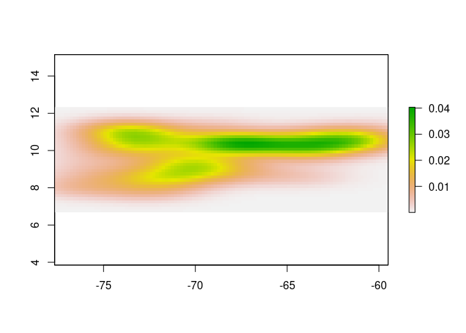

```r
#criamos o raster usando os valores do objeto dens
#e os valores de env
dens.ras <- raster(dens, env)
#Agoras colocamos dens.ras na mesma resolução das camadas ambientais
dens.ras2 <- resample(dens.ras, env)
plot(dens.ras2)
```

Note que o raster de densidade é varia de acordo com a concentraçõ de pontos que tinhamos de *Heteromys anomalus* no iníncio. Essa camada pode então ser utilizada como informação para o MaxEnt ou outros algortmos para amostrar mais o background nesse região do que em outras.

Para salvar o raster podemos utilizar a seguinte linha:

```r
writeRaster(dens.ras2, "./biasfile.grd", overwrite=T)
```

```
## class      : RasterLayer
## dimensions : 34, 109, 3706  (nrow, ncol, ncell)
## resolution : 0.1666667, 0.1666667  (x, y)
## extent     : -77.66667, -59.5, 6.666667, 12.33333  (xmin, xmax, ymin, ymax)
## crs        : +proj=longlat +datum=WGS84 +no_defs
## source     : /media/wilson/MIDGARD/Documents/Academico/AARE - MNE/Aula 8 - Autocorrelacao/biasfile.grd
## names      : layer
## values     : 1.173139e-09, 0.0403418  (min, max)
```

# Estratégia 2: Filtrando por distância mínima

Nessa estratégia, ao invés de informarmos o viés da amostragem, tentaremos removê-la. Para isso utilizaremos a aleatorização do pacote `spThin`, utiliando os mesmos dados que já temos. Vamos realizar a filtrangem tanto no espaço geográfico quanto no espaço ambiental.

## Filtro Geográfico

Nessa estratégia, vamos setar um valor mínimo de distância em quilômetros os quais nossos pontos devem estar uns dos outros.

```r
thinned_data <-
  thin(
  loc.data  = df, #dataframe com os dados de ocorrência
  lat.col   = "LAT", #coluna com info de latitude
  long.col  = "LONG", #coluna com info de longitude
  spec.col  = "SPEC", #coluna com nome da espécie
  thin.par  = 10, #distância mínima entre pontos (em Km)
  reps      = 100, # numero de repetições
  locs.thinned.list.return = TRUE, #retornar a lista com os dataframes selecionados
  write.files = FALSE,
  write.log.file = FALSE
)
```

```
##  Beginning Spatial Thinning.
##  Script Started at: Mon May  3 20:39:46 2021
## lat.long.thin.count
## 122 123 124
##  11  46  43
## [1] "Maximum number of records after thinning: 124"
## [1] "Number of data.frames with max records: 43"
## [1] "No files written for this run."
```

Podemos olhar a tabela da primeira solução selecionada e plotá-la para ver como ficou:

```r
head(thinned_data[[1]])
```

```
##   Longitude  Latitude
## 1 -75.20000  7.883333
## 2 -76.73333  8.000000
## 3 -75.03333 10.616667
## 4 -74.06667  8.633333
## 5 -75.06667  9.966667
## 6 -73.38333 10.216667
```

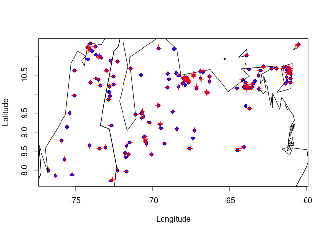

```r
plot(thinned_data[[1]], col="blue", pch=16)
  plot(wrld_simpl, add=T)
  points(df[,3:2], col="red", pch=3)
```

Os pontos azuis preenchidos (`pch=16, col ="blue"`) correnspondem aos dados selecionados, enquanto os pontos representados por cruzes vermelhas (`pch=3, col="red"`) representam os pontos excluídos.

Então vamos olhar mais de perto entre as longitudes -68.5 e -67.5 e latitudes 10.1, 10.6, onde a extenção total no eixo `x` deve corresponder a cerca de 100 km:

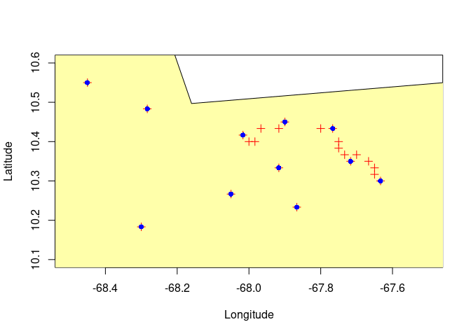

```r
  plot(thinned_data[[1]],
     xlim=c(-68.5,-67.5),
     ylim=c(10.1,10.6))
  plot(wrld_simpl,
     col="#FFFFAA",
     add=T)
  points(df[,3:2], pch=3, col="red", cex=1.1)
  points(thinned_data[[1]], col="blue", pch=16)
```

Note agora que fica muito mais fácil observar quais pontos foram excluídos e como eles são próximos uns aos outros.

## Estratégia 2.1: filtrar no espaço ambiental (bonus)

Como vimos na aula é possível filtrar os dados no espaço ambiental. Neste caso, assumiríamos que a proxímidade dos pontos naquele ambiente corresponderia a não independência dos dados, e de certo modo, uma repetição não aleatória da amostragem do nicho fundamental.

Neste caso, podemos utilizar a mesma lógica de aleatorização da função `thin` do pacote `spThin` com a diferença de fornecer um dataset com valores de coordenadas ambientais ao invés de latitudes e longitudes.

Nesta etapa do exercício iremos basicamente:  
1. Extrair dados ambientais a partir dos pontos de ocorrência 2. Reduzir o espaço via PCA 3. Avaliar um threshold 4. filtrar dados ambientais 5. observar os dados no espaço geográfico a partir do filtro ambiental

#### 1. Extrair dados ambientais

O primeiro passo a aqui é extrair os dados ambientais a partir dos nossos pontos de ocorrência

```r
#extraindo dados ambientais e criando um data.frame para a função `thin`
env.values<-extract(env, occ)
head(env.values)
```

```
##      bio1 bio2 bio3 bio4 bio5 bio6 bio7 bio8 bio9 bio10 bio11 bio12 bio13 bio14
## [1,]  279  101   84  397  344  224  120  276  283   284   274  2560   364    26
## [2,]  264   78   89  218  308  221   87  261  265   266   261  2414   298    80
## [3,]  278   97   82  405  336  218  118  277  276   282   273  1114   198     4
## [4,]  276  104   84  450  341  218  123  272  275   281   270  2020   347    15
## [5,]  264  113   77  463  337  191  146  262  260   269   257  1336   200    25
## [6,]  281  118   80  593  356  210  146  276  279   287   272  1308   204    15
##      bio15 bio16 bio17 bio18 bio19
## [1,]    58  1055   135   299  1009
## [2,]    34   770   276   422   770
## [3,]    71   517    21   188   168
## [4,]    62   859    82   270   821
## [5,]    52   503   103   355   374
## [6,]    58   517    59   187   357
```

Podemos plotar esses dados:

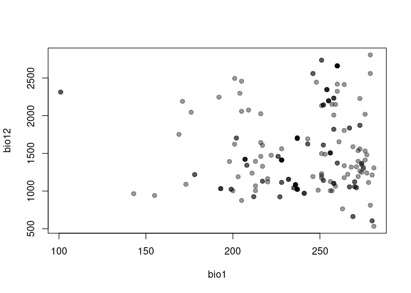

```r
plot(env.values[,c(1,12)], col=rgb(0,0,0,0.4), pch=20, cex=1.5)
```

Neste gráfico, visualizamos a relação dos dados extraídos a partir de todos os nossos pontos de ocorrência em um espaço ambiental composto por apenas duas variáveis `bio1: temperatura` e `bio12: precipitação`

Note que há um valor de alpha na cor preta nos pontos do gráfico, ou seja, pontos mais escuros são sobreposições nesse espaço, logo são pontos que gostaríamos de remover.

Um aspecto muito importante é que estamos olhando apenas duas variáveis nesse plot, e os pontos de ocorrência podem ter outra relação quando considerarmos outras variáveis. Para tentar lidar com esse problema, iremos construir um espaço ambiental via PCA. Assim, estaremos olhando não mais para cada variável por vez, mas para os componentes que reduzem a variância entre elas. Vejamos isso de forma mais concreta a seguir.

#### 2. Reduzindo as dimensões com uma PCA

Gerar PCAs no R é simples, basta utilizar a função `prcomp`. Há vários pacotes dedicados à isso, mas para o nosso propósito aqui, essa função será mais que suficiente.  
Na linha a seguir, processamos um PCA a partir dos dados ambientais (`env.values`) corrigindo as coordenadas dos pontos no centro de variância (`center = T`) e bem como sua escala (`scale. = T`). Além disso, sumarizamos os resultados com a função `summary()`

```r
pca<- prcomp(env.values, center = T, scale. = T)

summary(pca)
```

```
## Importance of components:
##                           PC1    PC2    PC3     PC4     PC5     PC6     PC7
## Standard deviation     2.7069 2.3057 1.5555 1.36112 1.00070 0.77038 0.45284
## Proportion of Variance 0.3856 0.2798 0.1273 0.09751 0.05271 0.03124 0.01079
## Cumulative Proportion  0.3856 0.6655 0.7928 0.89031 0.94301 0.97425 0.98504
##                            PC8     PC9    PC10    PC11    PC12    PC13    PC14
## Standard deviation     0.40720 0.25090 0.15881 0.10816 0.09217 0.07164 0.04535
## Proportion of Variance 0.00873 0.00331 0.00133 0.00062 0.00045 0.00027 0.00011
## Cumulative Proportion  0.99377 0.99708 0.99841 0.99903 0.99947 0.99974 0.99985
##                           PC15    PC16    PC17    PC18      PC19
## Standard deviation     0.03766 0.03310 0.01349 0.01093 5.882e-16
## Proportion of Variance 0.00007 0.00006 0.00001 0.00001 0.000e+00
## Cumulative Proportion  0.99993 0.99998 0.99999 1.00000 1.000e+00
```

Note que a variância acumulada (`Cumulative Proportion`) aumenta a medida que os componentes são adicionados. Neste exemplo, vemos que os cinco primeiros componentes já retém mais de 94% da variância. Com isso, sabemos que é complemente possível continuar a análise considerando apenas esses primeiros cinco componentes.

Agora vamos plotar as coordenadas dos nossos pontos nos dois primeiros componentes (“66% da variância”) com: `plot(pca$x)`. Note ainda que mudei apenas as cor para preto `rgb(0,0,0)` com transparência (“alfa”) de 30% (o último 0 do rgb). A forma é um círculo preenchido (`pch=20`) e o tamanho é uma vez e meia (`cex = 1.5`)

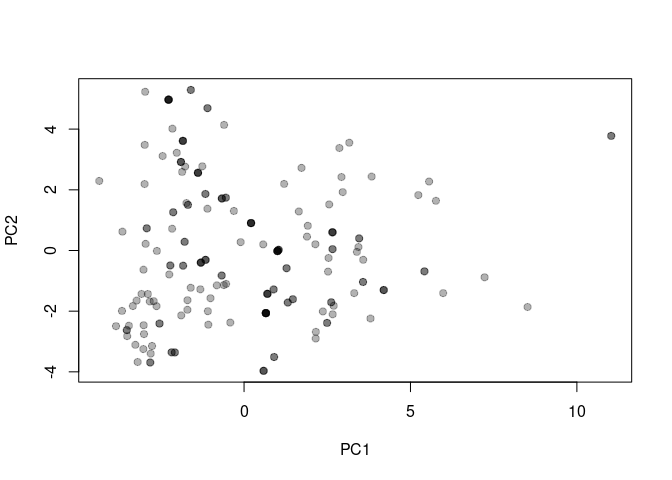

```r
plot(pca$x, col=rgb(0,0,0,0.3), pch=20, cex=1.5)
```

Interessantemente temos mais uma vez pontos mais escuros que significam sobreposição. Um outro detalhe é que, olhando a disposição dos pontos, fica difícil dizer qual a distância mínima que um ponto deve estar de outro para decidirmos como filtrá-los. Neste caso, precismos identificar um threshold.